# Daily Gym Workout Observations

## What is this data about?

This visual data story explores my personal gym workout observations collected over two weeks in April and May 2026. Each time I went to the gym, I logged the type of routine I performed (Push, Pull, or Legs), the day of the week, how many minutes I spent working out, and how crowded the gym was.

The data was collected using a Google Form and contains **40 observations** in total. The goal is to uncover patterns in my workout habits — do certain routines take longer? Are some days busier at the gym than others?

## How long do different routines take?

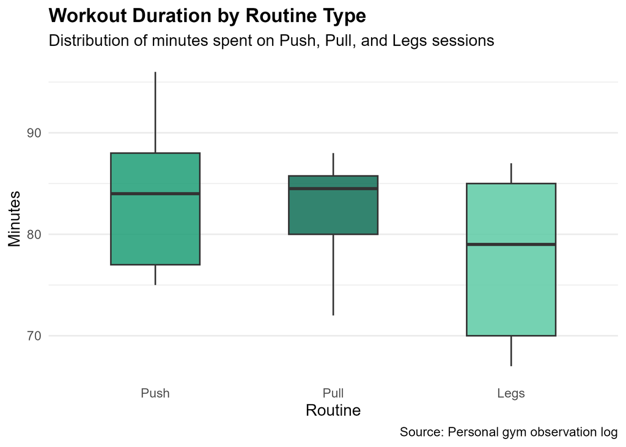

## Does the day of the week affect workout length?

Here, I look at the average workout duration grouped by day of the week. Monday sessions tend to be the longest, possibly due to higher motivation at the start of the week. Weekend sessions (Saturday and Sunday) are noticeably shorter on average, which may reflect a more relaxed approach to training.

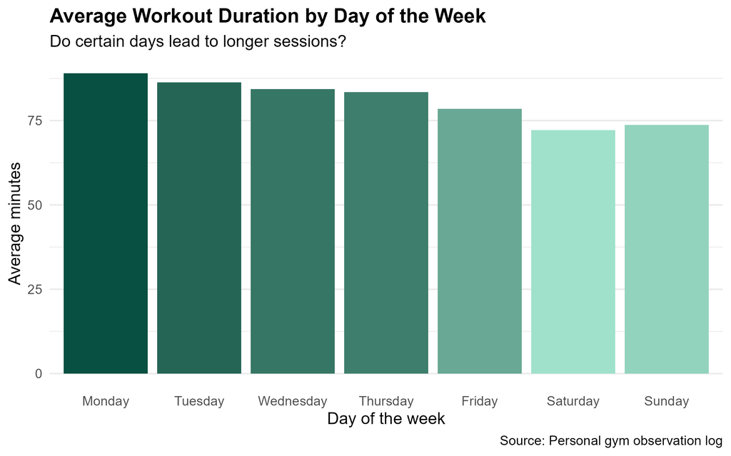

## How has my workout duration changed over time?

This line plot tracks each gym session in chronological order, coloured by routine type. There is no strong upward or downward trend overall, but some sessions — particularly Push days — stand out as notably longer. The data spans two separate weeks of logging.

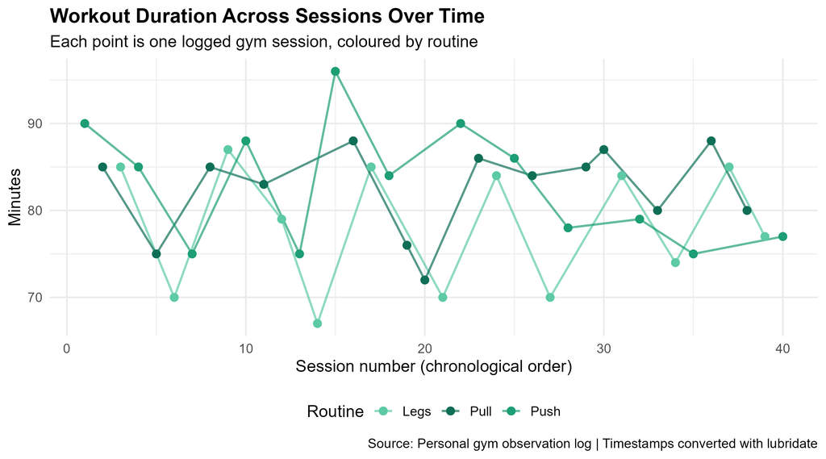

Line plot showing workout duration across 40 sessions over time, with each point coloured by routine type: green for Push, dark green for Pull, and light teal for Legs.

## How crowded is the gym for each routine?

Finally, this stacked bar chart shows the proportion of crowding levels experienced during each routine type. Push sessions were more often done on Very Busy days, while Legs sessions were more frequently done when the gym was Quiet or Very Quiet. This may reflect the days of the week I tend to do each routine.

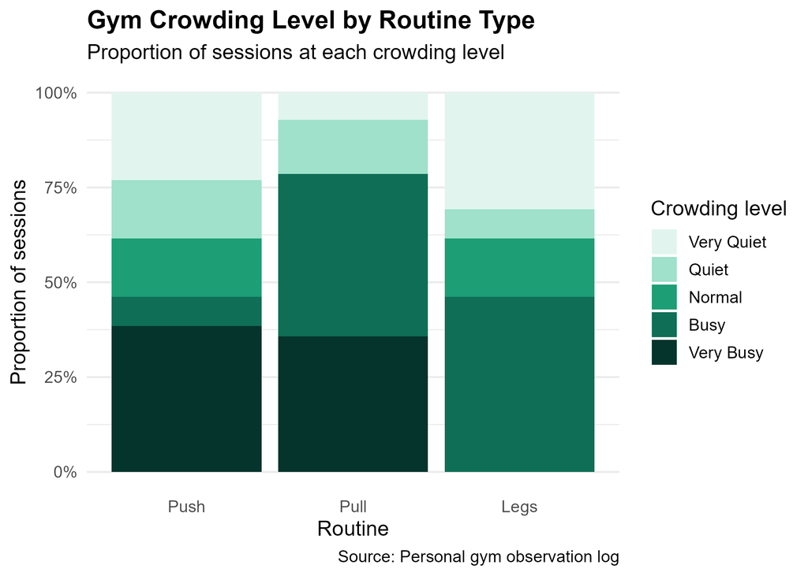

Stacked bar chart showing the proportion of gym crowding levels (Very Quiet to Very Busy) for each routine type: Push, Pull, and Legs.

## What does this all mean?

This data was collected and logged by myself alone, using a Google Form linked to a Google Sheets spreadsheet. The visualisations were created in R using the `{ggplot2}` and `{lubridate}` packages, with a consistent teal colour theme applied throughout.